# Communicating Data

Stephanie Duncan

18/01/2021

# NYC Citi Bike Trips

A sample of data from NYC Citi Bike shows event data on the usage of 10 bikes throughout 2018. As well as event data, the sample data includes information on the customers and subscribers hiring bikes such as gender and birth year. A customer is defined as being someone who has purchased a 24-hour or 3-day pass, whereas a subscriber purchases an annual subscription.

A variety of data visualisations were created to understand the following:

1. The pattern of bike hires over time
2. Bike hire patterns and bike rider demographics:
   1. gender
   2. type of user
   3. age
3. The geographical spread of the start points of bike hires

## 1. The Pattern of Bike Hires over Time

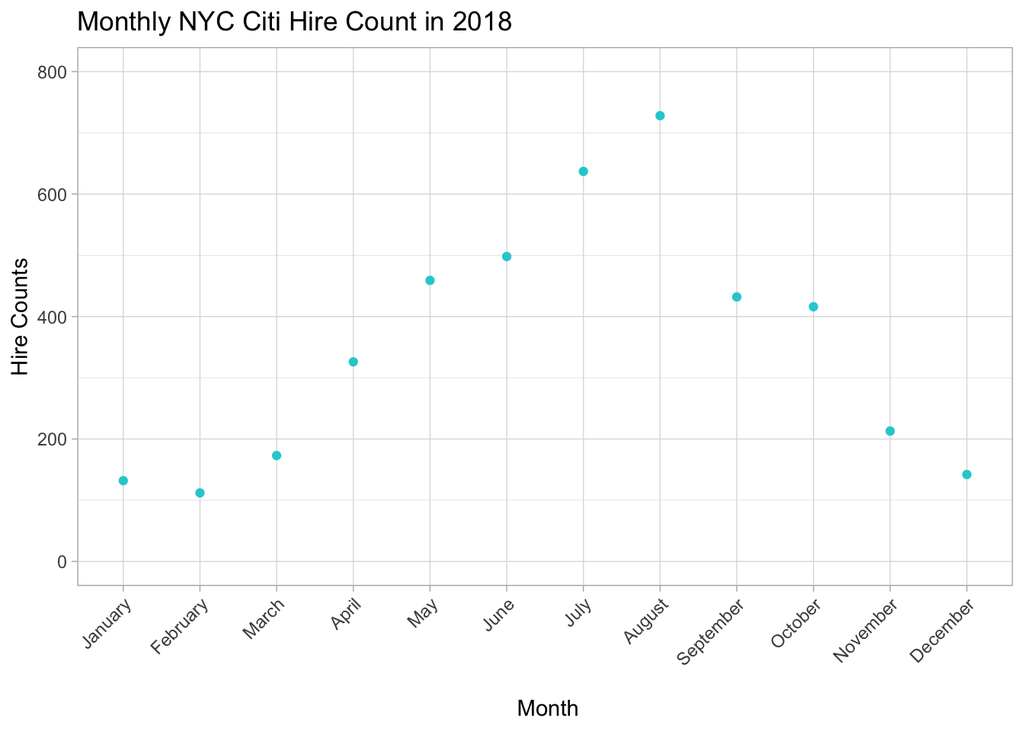

The graph shows bike usage is low in January and February, followed by a continuous increase from February through to August, where bike hire peaks to over 700 hires. From August, there is a decrease in bike usage through to December. The months with the lowest performance are January, February, March and December where there are below 200 hires.

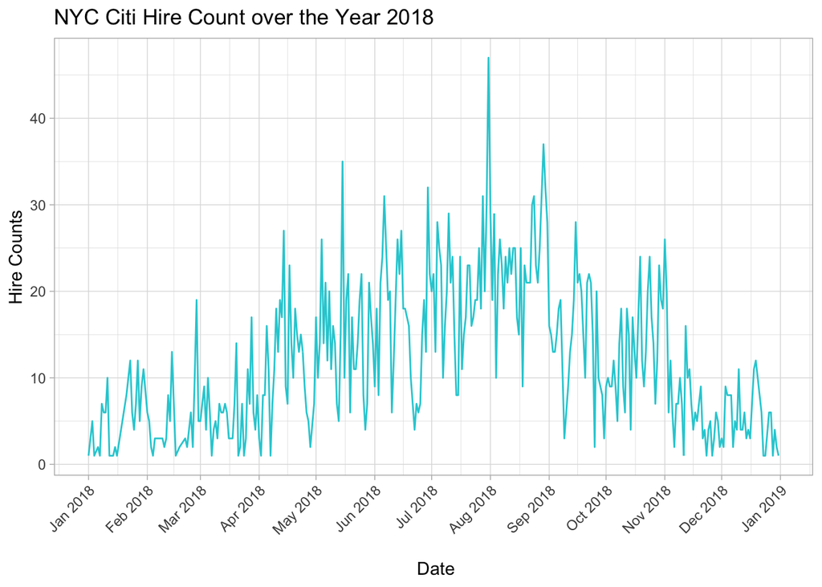

After taking a closer look at hire count over the year, the graph shows an irregular pattern for bike usage.

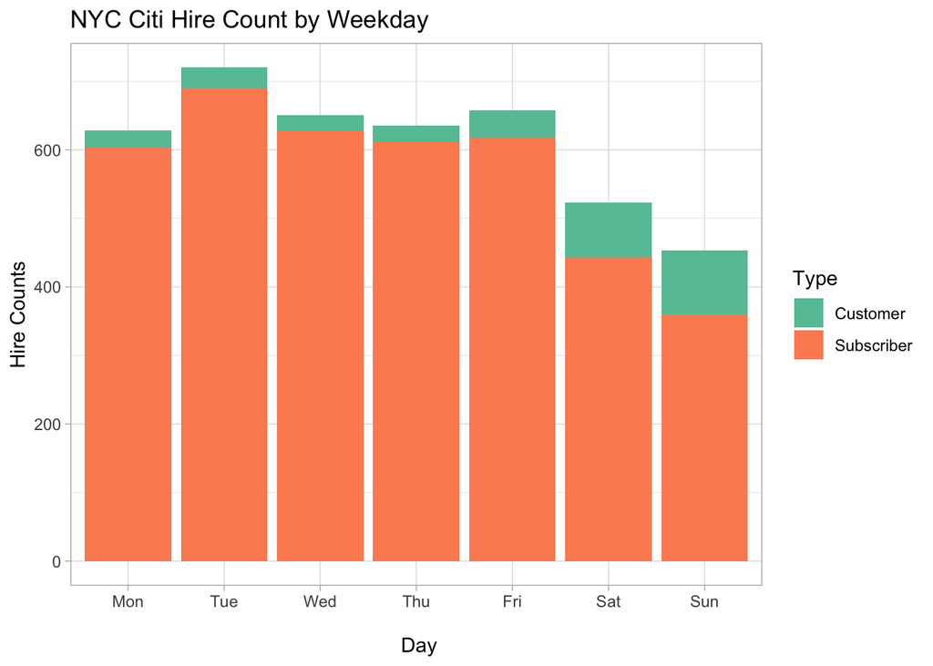

There are more bike hires on working days than there are at weekends for subscribers, whereas more customers hire a bike on Saturdays and Sundays than during the week.

## 2. Bike Hire Patterns by Bike Rider Demographics

### 2.1 Bike Hire Patterns by User Type

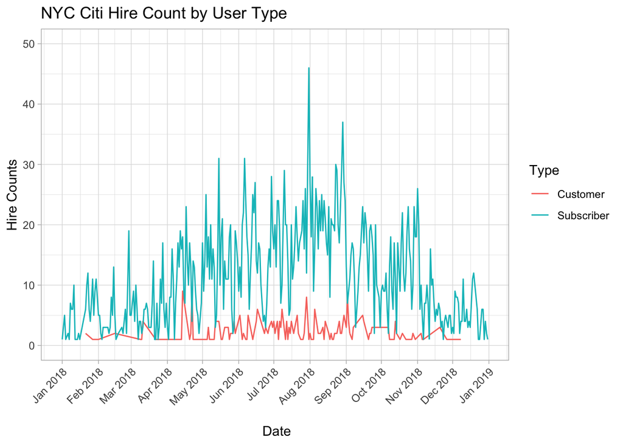

After grouping bike hires by user, the graph again shows irregularity, however it can be seen that there is significantly more subscribers hiring bikes than customers. Subscribers are using their hired bike throughout the entire year, whereas customers hired a bike mostly between April and October. Very few customers hired a bike from January to March, and November and December.

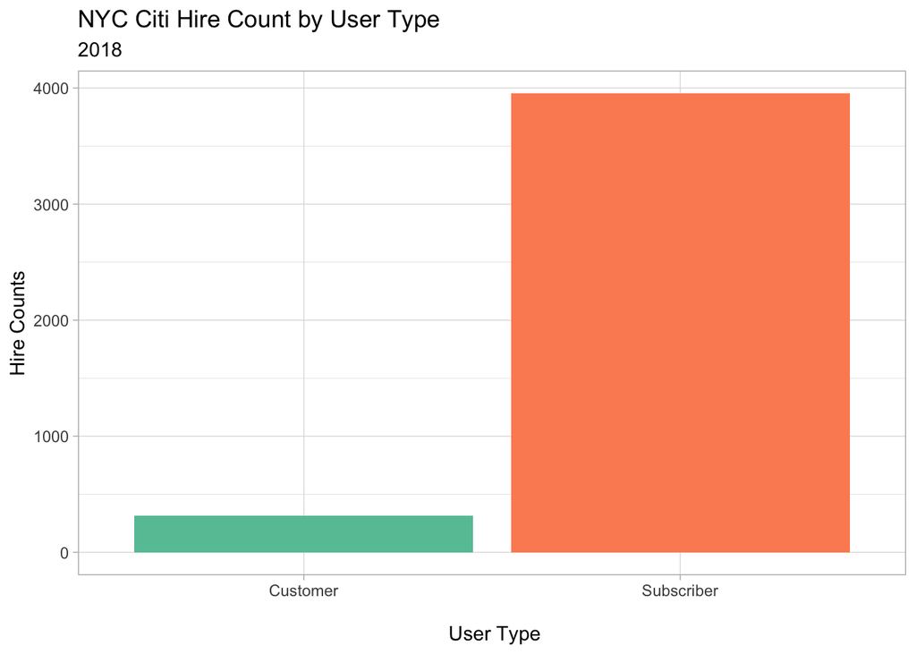

There are almost a total of 4000 subscribers hiring bikes, compared to 315 customers (7.4%).

### 2.2 Bike Hire Patterns by Gender of User

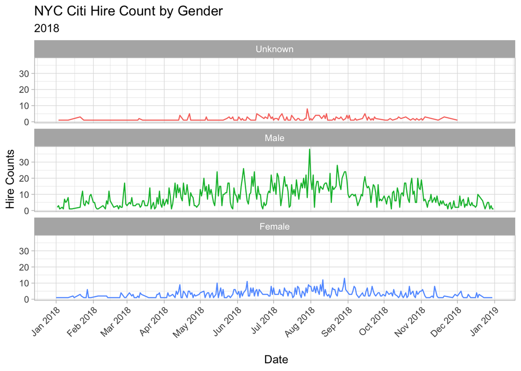

The graph shows that significantly more bikes are hired by males than females and those of unknown gender. Data for unknown genders have been included in this analysis so as not to lose a significant proportion of the data, which may have introduced bias.

### 2.3 Bike Hire Patterns by User Age

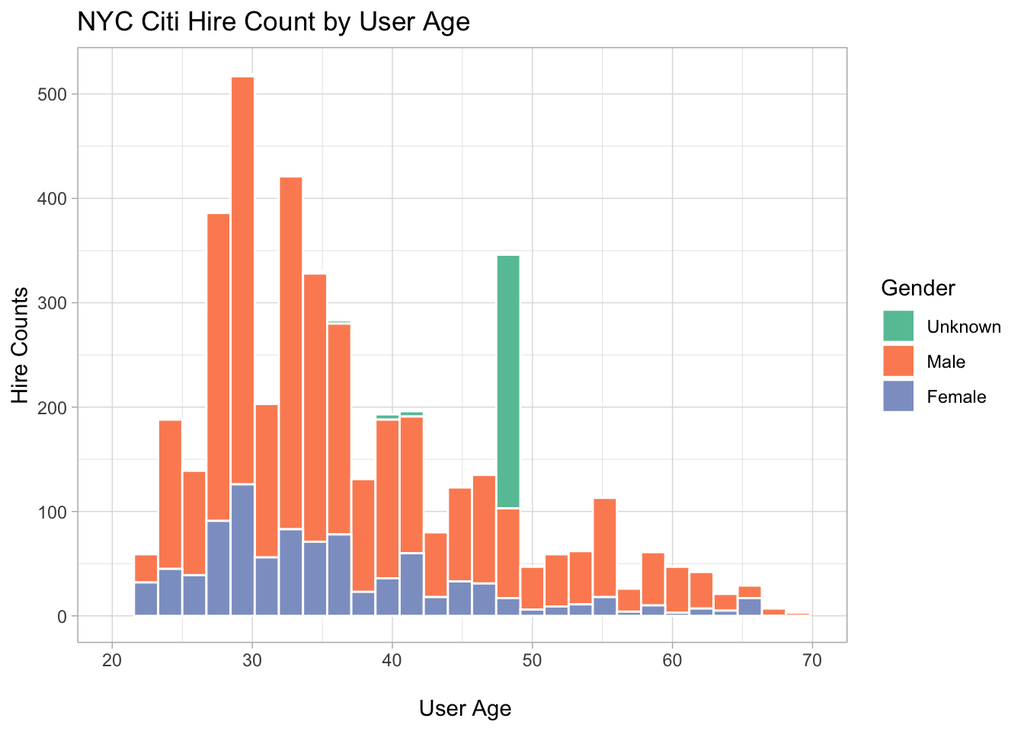

The graph shows there are similar distributions for both males and females, however a higher proportion of males hire bikes than females. Most bike hires are from males and females aged 26-38 years old. The graph also shows a considerable number of users aged 49 of unknown gender hiring bikes.

## 3. The Geographical Spread of the Start Points of Bike Hires

[interactive chart not shown]

### The Top 5 Most Popular Start Stations

[interactive chart not shown]

The geographical spread of the start points of bike hires shows a prominent cluster around Grove Street and the coast of the Hudson River. Start station 3186 is the most popular (Grove Street), followed by 3203, 3195, 3183 and 3202.

# Conclusions/Recommendations

1. For January, February, March and December, the months where hire counts are lowest, consideration should be made to make hiring a bike during these months more appealing to users perhaps by charging a lower rate for customers.
2. On working days, hire count from subscribers is consistently high, however there is opportunity to increase the number of bike hires from customers on working days.
3. As start stations are most popular around Grove Street and the coast of the Hudson River, more stations could be added to these areas to increase hire counts.